# Latihan-67.Rmd

Lutfi Syahreza Lubis

2023-10-02

## Packages

```r
library(ggplot2)
library(tsibble)
library(tseries)
library(MASS)
library(forecast)
library(TSA)
library(TTR)
library(aTSA)
library(graphics)
```

## Importing data

```r
data_air <- rio::import("https://raw.githubusercontent.com/lutfi-reza/mpdw-lutfi-reza/main/data/data_air.csv")
data_air <- data_air$tinggi_air[1:200]
```

## Eksplorasi Data

### Plot Data Penuh

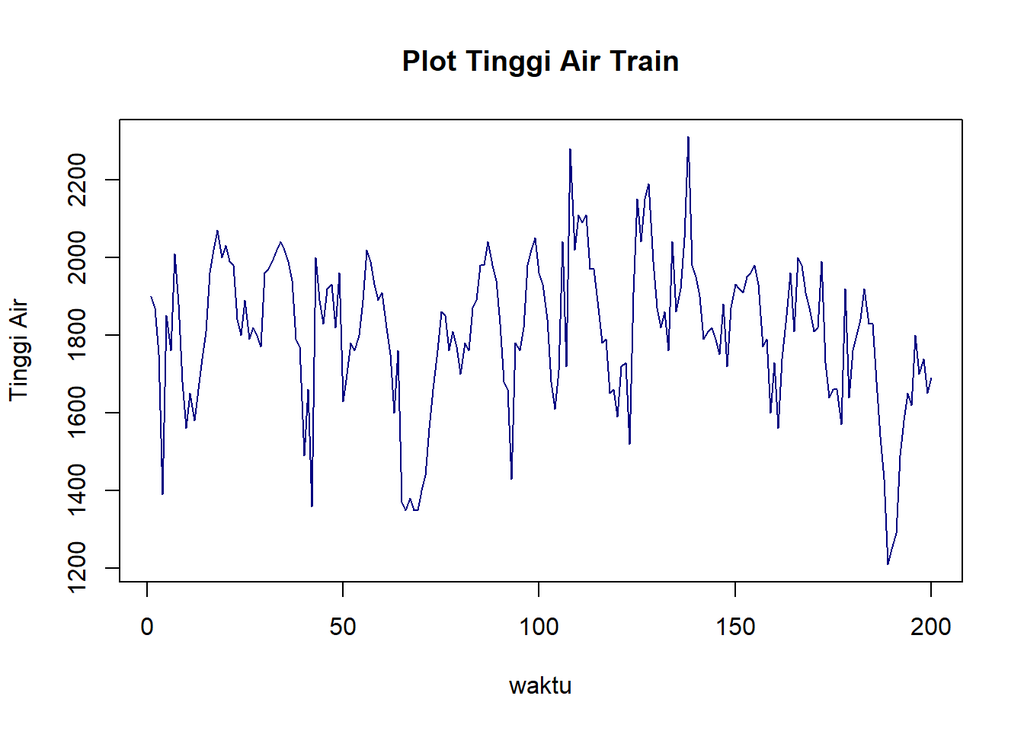

```r
data_air.ts <- ts(data_air)
plot.ts(data_air.ts, col = "navyblue", lty=1, xlab="waktu", ylab="Tinggi Air", main="Plot Tinggi Air Train")
```

Berdasarkan plot data deret waktu, terlihat bahwa data memiliki pola konstan. Berdasarkan pola data, pembagian data latih dan data uji ditetapkan dengan proporsi 80% dan 20%.

## Plot Data Latih

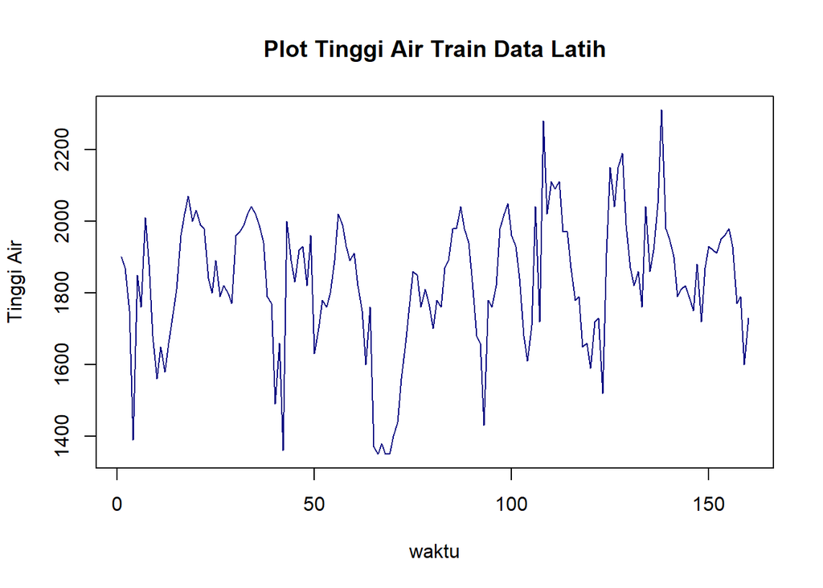

```r
data_air.train <- data_air[1:160]
train.ts <- ts(data_air.train)
plot.ts(train.ts, col = "navyblue", lty=1, xlab="waktu", ylab="Tinggi Air", main="Plot Tinggi Air Train Data Latih")
```

Berdasarkan plot data deret waktu pada lata latih, terlihat bahwa data memiliki pola konstan yang bergerak pada nilai tengah tertentu. Hal ini mengindikasikan data stasioner dalam rataan.

## Plot Data Uji

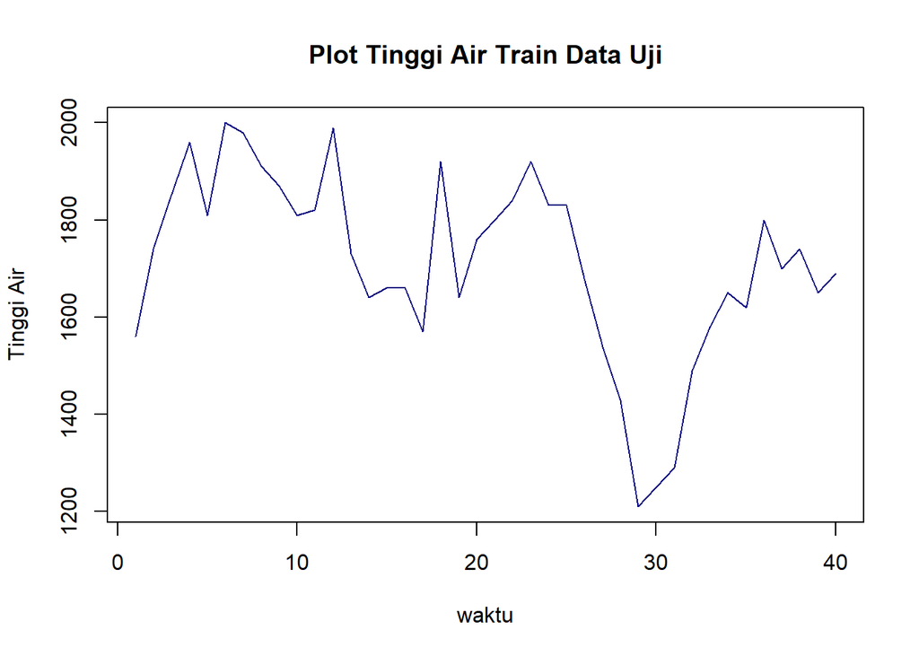

```r
data_air.test <- data_air[161:200]
test.ts <- ts(data_air.test)
plot.ts(test.ts, col = "navyblue", lty=1, xlab="waktu", ylab="Tinggi Air", main="Plot Tinggi Air Train Data Uji")
```

### Uji Stasioneritas Data

#### Plot ACF

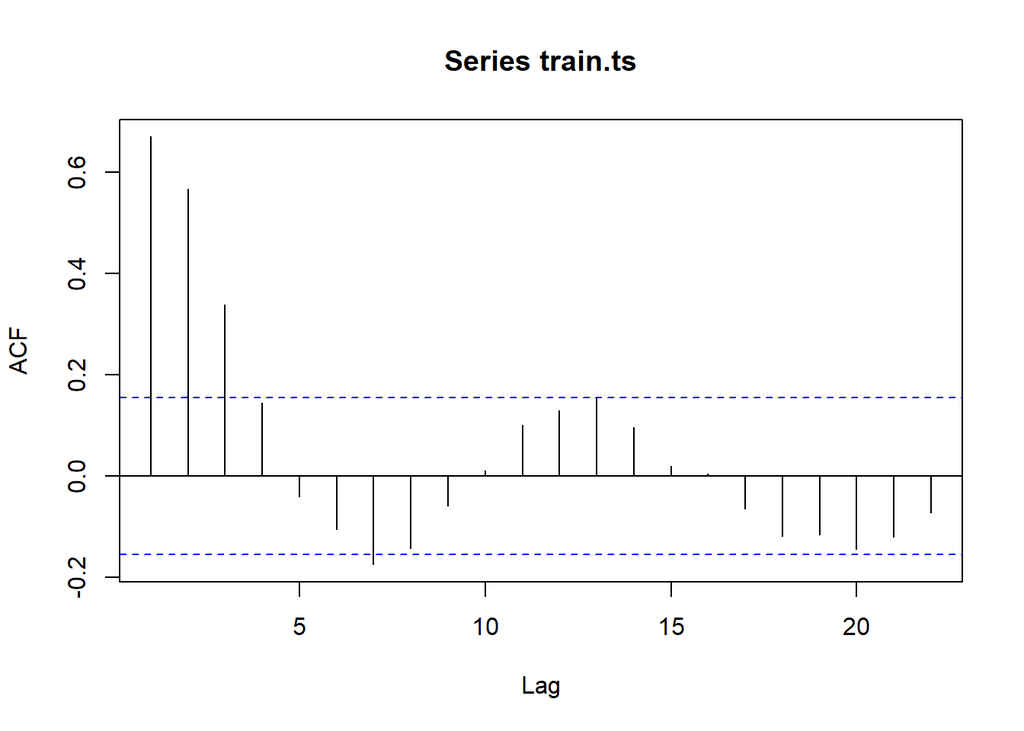

```r
acf(train.ts)
```

Berdasarkan plot ACF, terlihat bahwa plot ACF data menurun *tails off* dan memiliki pola cosinus. Hal ini mengindikasikan bahwa data stasioner dalam rataan.

#### Uji ADF

```r
tseries::adf.test(train.ts)
```

```
##
##  Augmented Dickey-Fuller Test
##
## data:  train.ts
## Dickey-Fuller = -4.7537, Lag order = 5, p-value = 0.01
## alternative hypothesis: stationary
```

$H_0$ : Data tidak stasioner dalam rataan

$H_1$ : Data stasioner dalam rataan

Berdasarkan uji ADF tersebut, didapat *p-value* sebesar 0.01 yang lebih kecil dari taraf nyata 5% sehingga tolak $H_0$ dan menandakan bahwa data stasioner dalam rataan. Hal ini sesuai dengan hasil eksplorasi menggunakan plot time series dan plot ACF.

#### Plot Box-Cox

```r
index <- seq(1:160)
bc = MASS::boxcox(train.ts~index, lambda = seq(0,4,by=0.5))
```

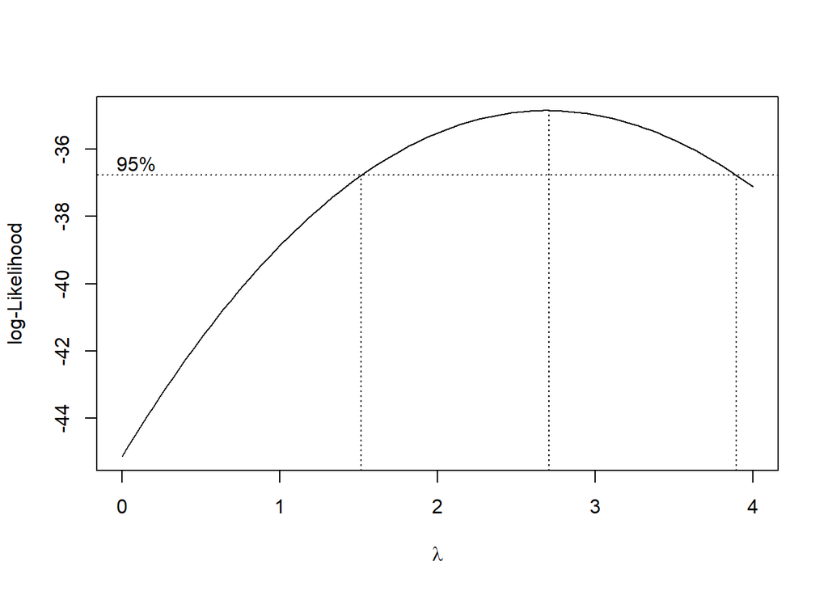

```r
#Nilai Rounded Lambda
lambda <- bc$x[which.max(bc$y)]
lambda
```

```
## [1] 2.707071
```

```r
#SK
bc$x[bc$y > max(bc$y) - 1/2 * qchisq(.95,1)]
```

```
##  [1] 1.535354 1.575758 1.616162 1.656566 1.696970 1.737374 1.777778 1.818182
##  [9] 1.858586 1.898990 1.939394 1.979798 2.020202 2.060606 2.101010 2.141414
## [17] 2.181818 2.222222 2.262626 2.303030 2.343434 2.383838 2.424242 2.464646
## [25] 2.505051 2.545455 2.585859 2.626263 2.666667 2.707071 2.747475 2.787879
## [33] 2.828283 2.868687 2.909091 2.949495 2.989899 3.030303 3.070707 3.111111
## [41] 3.151515 3.191919 3.232323 3.272727 3.313131 3.353535 3.393939 3.434343
## [49] 3.474747 3.515152 3.555556 3.595960 3.636364 3.676768 3.717172 3.757576
## [57] 3.797980 3.838384 3.878788
```

Plot Boxcox menunjukkan nilai *rounded value* ($\lambda$) optimum sebesar **2.707071** dan pada selang kepercayaan 95% nilai memiliki batas bawah **1.535354** dan batas atas **3.878788**. Selang tersebut tidak memuat nilai satu sehingga dapat dikatakan bahwa data tidak stasioner dalam ragam.

## Tidak Ada Penanganan Ketidakstasioneran Data

### Identifikasi Model

#### Plot ACF

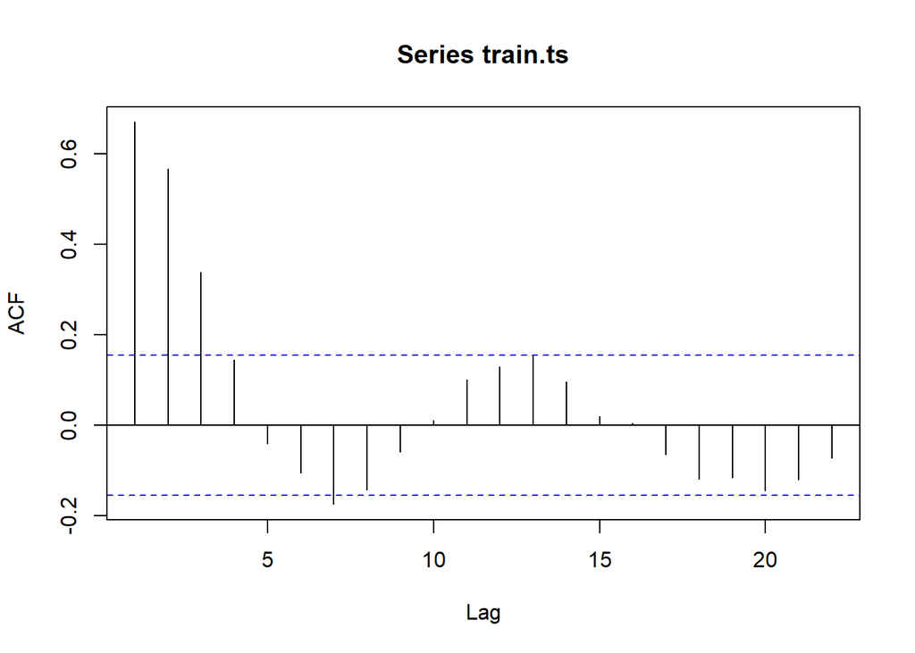

```r
acf(train.ts)
```

Berdasarkan plot tersebut, terlihat bahwa plot ACF cenderung *tails off*.

#### Plot PACF

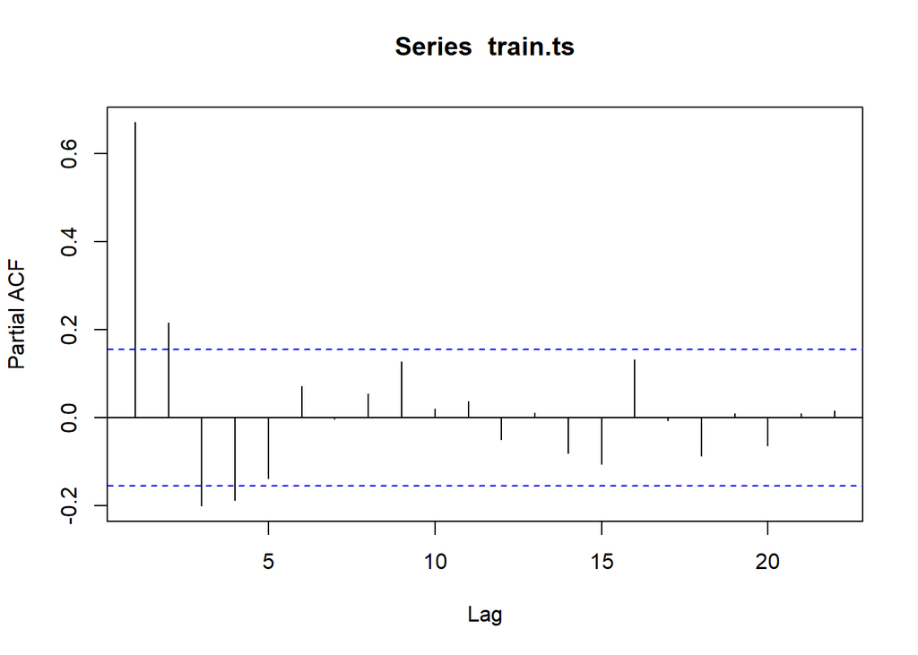

```r
pacf(train.ts)
```

Berdasarkan plot tersebut, terlihat bahwa plot PACF cenderung *cuts off* pada lag ke 4, sehingga jika plot ACF dianggap *tails off*, maka model tentatifnya adalah ARIMA(4,0,0) atau AR(4).

#### Plot EACF

```r
eacf(train.ts)
```

```
## AR/MA
##   0 1 2 3 4 5 6 7 8 9 10 11 12 13
## 0 x x x o o o x o o o o  o  o  o
## 1 x x x x o o o o o o o  o  o  o
## 2 x x o o o o o o o o o  o  o  o
## 3 x o x o o x o o o o o  o  o  o
## 4 x o x x o o o o o o o  o  o  o
## 5 x x x o o o o o o o o  o  o  o
## 6 x x o x o o o o o o o  o  o  o
## 7 x o o x o o o o o o o  o  o  o
```

Identifikasi model menggunakan plot EACF dilakukan dengan melihat ujung segitiga pada pola segitiga nol. Dalam hal ini model tentatif yang terbentuk adalah ARIMA(0,0,3) atau MA(3) dan ARIMA(2,0,2), atau ARMA (2,2).

### Pendugaan Parameter Model Tentatif

#### AR(4) atau ARIMA(4,0,0)

```r
model1.da=Arima(train.ts, order=c(4,0,0),method="ML")
summary(model1.da) #AIC=2020.32
```

```
## Series: train.ts
## ARIMA(4,0,0) with non-zero mean
##
## Coefficients:
##          ar1     ar2      ar3      ar4       mean
##       0.5242  0.3999  -0.0872  -0.2129  1833.1212
## s.e.  0.0767  0.0881   0.0876   0.0793    26.8822
##
## sigma^2 = 16976:  log likelihood = -1004.16
## AIC=2020.32   AICc=2020.87   BIC=2038.77
##
## Training set error measures:
##                      ME     RMSE      MAE        MPE     MAPE      MASE
## Training set -0.9486622 128.2384 92.14223 -0.5889207 5.201248 0.8694727
##                     ACF1
## Training set -0.02609748
```

```r
lmtest::coeftest(model1.da) # 4 dari 5 parameter signifikan
```

```
##
## z test of coefficients:
##
##              Estimate  Std. Error z value  Pr(>|z|)
## ar1          0.524223    0.076731  6.8320 8.374e-12 ***
## ar2          0.399909    0.088111  4.5387 5.660e-06 ***
## ar3         -0.087166    0.087605 -0.9950  0.319738
## ar4         -0.212927    0.079314 -2.6846  0.007262 **
## intercept 1833.121234   26.882196 68.1909 < 2.2e-16 ***
## ---
## Signif. codes:  0 '***' 0.001 '**' 0.01 '*' 0.05 '.' 0.1 ' ' 1
```

#### MA(3) atau ARIMA(0,0,3)

```r
model2.da=Arima(train.ts, order=c(0,0,3),method="ML")
summary(model2.da) #AIC=2030.33
```

```
## Series: train.ts
## ARIMA(0,0,3) with non-zero mean
##
## Coefficients:
##          ma1     ma2     ma3      mean
##       0.4827  0.5365  0.3009  1831.890
## s.e.  0.0767  0.0658  0.0650    24.282
##
## sigma^2 = 18211:  log likelihood = -1010.17
## AIC=2030.33   AICc=2030.72   BIC=2045.71
##
## Training set error measures:
##                      ME     RMSE      MAE       MPE     MAPE      MASE
## Training set -0.5758253 133.2507 97.22901 -0.679757 5.507983 0.9174725
##                    ACF1
## Training set 0.06615332
```

```r
lmtest::coeftest(model2.da) #seluruh parameter signifikan
```

```
##
## z test of coefficients:
##
##             Estimate Std. Error z value  Pr(>|z|)
## ma1       4.8270e-01 7.6733e-02  6.2907 3.161e-10 ***
## ma2       5.3647e-01 6.5763e-02  8.1575 3.420e-16 ***
## ma3       3.0086e-01 6.4988e-02  4.6294 3.667e-06 ***
## intercept 1.8319e+03 2.4282e+01 75.4425 < 2.2e-16 ***
## ---
## Signif. codes:  0 '***' 0.001 '**' 0.01 '*' 0.05 '.' 0.1 ' ' 1
```

#### ARMA (2,2) atau ARIMA(2,0,2)

```r
model3.da=Arima(train.ts, order=c(2,0,2),method="ML")
summary(model3.da) #AIC=2016.93
```

```
## Series: train.ts
## ARIMA(2,0,2) with non-zero mean
##
## Coefficients:
##          ar1      ar2      ma1     ma2       mean
##       1.4880  -0.7100  -0.9897  0.5583  1834.0976
## s.e.  0.1264   0.1151   0.1497  0.0958    25.6021
##
## sigma^2 = 16598:  log likelihood = -1002.46
## AIC=2016.93   AICc=2017.47   BIC=2035.38
##
## Training set error measures:
##                     ME     RMSE      MAE        MPE     MAPE      MASE
## Training set -1.269077 126.8025 89.37533 -0.5954706 5.065963 0.8433637
##                      ACF1
## Training set -0.008862183
```

```r
lmtest::coeftest(model3.da) #seluruh parameter signifikan
```

```
##
## z test of coefficients:
##
##              Estimate  Std. Error z value  Pr(>|z|)
## ar1          1.488008    0.126375 11.7745 < 2.2e-16 ***
## ar2         -0.710047    0.115100 -6.1690 6.873e-10 ***
## ma1         -0.989697    0.149687 -6.6118 3.798e-11 ***
## ma2          0.558302    0.095796  5.8280 5.609e-09 ***
## intercept 1834.097649   25.602123 71.6385 < 2.2e-16 ***
## ---
## Signif. codes:  0 '***' 0.001 '**' 0.01 '*' 0.05 '.' 0.1 ' ' 1
```

Berdasarkan pendugaan parameter di atas, nilai AIC terkecil dimiliki oleh model ARIMA(2,0,2) dan parameter model ARIMA(2,0,2) juga seluruhnya signifikan sehingga model yang dipilih adalah model ARIMA(2,0,2).

### Analisis Sisaan

Model terbaik hasil identifikasi kemudian dicek asumsi sisaannya. Sisaan model ARIMA harus memenuhi asumsi normalitas, kebebasan sisaan, dan kehomogenan ragam. Diagnostik model dilakukan secara eksplorasi dan uji formal.

#### Eksplorasi Sisaan

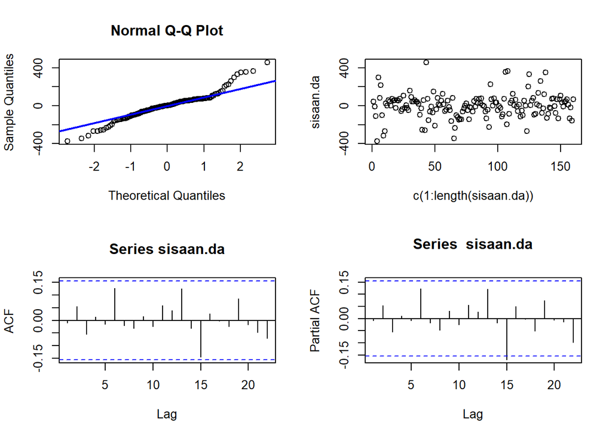

```r
#Eksplorasi
sisaan.da <- model3.da$residuals
par(mfrow=c(2,2))
qqnorm(sisaan.da)
qqline(sisaan.da, col = "blue", lwd = 2)
plot(c(1:length(sisaan.da)),sisaan.da)
acf(sisaan.da)
pacf(sisaan.da)
```

```r
par(mfrow = c(1,1))
```

Berdasarkan plot kuantil-kuantil normal, secara eksplorasi ditunjukkan sisaan tidak menyebar normal ditandai dengan titik titik yang cenderung tidak mengikuti garis $45^{\circ}$. Kemudian dapat dilihat lebar pita sisaan yang cenderung sama menandakan bahwa sisaan memiliki ragam yang homogen. Plot ACF sisaan ARIMA(2,0,2) juga tidak signifikan pada 20 lag awal yang menandakan saling bebas. Kondisi ini akan diuji lebih lanjut dengan uji formal.

#### Uji Formal

```r
#1) Sisaan Menyebar Normal
ks.test(sisaan.da,"pnorm")  #tak tolak H0 > sisaan menyebar normal
```

```
##
##  Asymptotic one-sample Kolmogorov-Smirnov test
##
## data:  sisaan.da
## D = 0.49359, p-value < 2.2e-16
## alternative hypothesis: two-sided
```

Selain dengan eksplorasi, asumsi tersebut dapat diuji menggunakan uji formal. Pada tahapan ini uji formal yang digunakan untuk normalitas adalah uji Kolmogorov-Smirnov (KS). Hipotesis pada uji KS adalah sebagai berikut.

$H_0$ : Sisaan menyebar normal

$H_1$ : Sisaan tidak menyebar normal

Berdasarkan uji KS tersebut, didapat *p-value* sebesar 0.00 yang kurang dari taraf nyata 5% sehingga tolak $H_0$ dan menandakan bahwa sisaan tidak menyebar normal. Hal ini sesuai dengan hasil eksplorasi menggunakan plot kuantil-kuantil normal.

```r
#2) Sisaan saling bebas/tidak ada autokorelasi
Box.test(sisaan.da, type = "Ljung")  #tak tolak H0 > sisaan saling bebas
```

```
##
##  Box-Ljung test
##
## data:  sisaan.da
## X-squared = 0.012803, df = 1, p-value = 0.9099
```

Selanjutnya akan dilakukan uji formal untuk kebebasan sisaan menggunakan uji Ljung-Box. Hipotesis yang digunakan adalah sebagai berikut.

$H_0$ : Sisaan saling bebas

$H_1$ : Sisaan tidak tidak saling bebas

Berdasarkan uji Ljung-Box tersebut, didapat *p-value* sebesar 0.9099 yang lebih besar dari taraf nyata 5% sehingga tak tolak $H_0$ dan menandakan bahwa sisaan saling bebas.

```r
#3) Sisaan homogen
Box.test((sisaan.da)^2, type = "Ljung")  #tak tolak H0 > sisaan homogen
```

```
##
##  Box-Ljung test
##
## data:  (sisaan.da)^2
## X-squared = 8.4946, df = 1, p-value = 0.003562
```

Hipotesis yang digunakan untuk uji kehomogenan ragam adalah sebagai berikut.

$H_0$ : Ragam sisaan homogen

$H_1$ : Ragam sisaan tidak homogen

```r
#4) Nilai tengah sisaan sama dengan nol
t.test(sisaan.da, mu = 0, conf.level = 0.95)  #tak tolak h0 > nilai tengah sisaan sama dengan 0
```

```
##
##  One Sample t-test
##
## data:  sisaan.da
## t = -0.12621, df = 159, p-value = 0.8997
## alternative hypothesis: true mean is not equal to 0
## 95 percent confidence interval:
##  -21.12882  18.59067
## sample estimates:
## mean of x
## -1.269077
```

Terakhir, dengan uji-t, akan dicek apakah nilai tengah sisaan sama dengan nol. Hipotesis yang diujikan sebagai berikut.

$H_0$ : nilai tengah sisaan sama dengan 0

$H_1$ : nilai tengah sisaan tidak sama dengan 0

Berdasarkan uji-ttersebut, didapat *p-value* sebesar 0.8997 yang lebih besar dari taraf nyata 5% sehingga tak tolak $H_0$ dan menandakan bahwa nilai tengah sisaan sama dengan nol.

### Overfitting

Tahapan selanjutnya adalah *overfitting* dilakukan dengan menaikkan orde AR(p) dan MA(q) dari model ARIMA(2,0,2) untuk melihat apakah terdapat model lain yang lebih baik dari model saat ini. Kandidat model *overfitting* adalah ARIMA(3,0,2) dan ARIMA(2,0,3).

```r
#---OVERFITTING---#

#ARIMA(3,0,2)
model1a.arma2=Arima(train.ts, order=c(3,0,2),method="ML")
summary(model1a.arma2) #AIC=2018.59
```

```
## Series: train.ts
## ARIMA(3,0,2) with non-zero mean
##
## Coefficients:
##          ar1      ar2      ar3      ma1     ma2       mean
##       1.3494  -0.4751  -0.1052  -0.8604  0.4445  1833.8945
## s.e.  0.2374   0.3590   0.1580   0.2357  0.1915    25.2923
##
## sigma^2 = 16675:  log likelihood = -1002.3
## AIC=2018.59   AICc=2019.33   BIC=2040.12
##
## Training set error measures:
##                     ME     RMSE      MAE        MPE     MAPE      MASE
## Training set -1.183176 126.6874 89.79336 -0.5903506 5.085442 0.8473083
##                     ACF1
## Training set 0.005976566
```

```r
lmtest::coeftest(model1a.arma2) #ar2 dan ar3 tidak signifikan
```

```
##
## z test of coefficients:
##
##             Estimate Std. Error z value  Pr(>|z|)
## ar1          1.34944    0.23743  5.6835  1.32e-08 ***
## ar2         -0.47506    0.35900 -1.3233 0.1857388
## ar3         -0.10524    0.15802 -0.6660 0.5054410
## ma1         -0.86040    0.23570 -3.6504 0.0002618 ***
## ma2          0.44453    0.19150  2.3213 0.0202718 *
## intercept 1833.89451   25.29233 72.5079 < 2.2e-16 ***
## ---
## Signif. codes:  0 '***' 0.001 '**' 0.01 '*' 0.05 '.' 0.1 ' ' 1
```

```r
#ARIMA(2,0,3)
model1b.arma2=Arima(train.ts, order=c(2,0,3),method="ML")
summary(model1b.arma2) #AIC=2018.73
```

```
## Series: train.ts
## ARIMA(2,0,3) with non-zero mean
##
## Coefficients:
##          ar1      ar2      ma1     ma2      ma3       mean
##       1.4927  -0.6976  -0.9978  0.5761  -0.0564  1833.9671
## s.e.  0.1312   0.1168   0.1523  0.1051   0.1253    25.4761
##
## sigma^2 = 16689:  log likelihood = -1002.37
## AIC=2018.73   AICc=2019.47   BIC=2040.26
##
## Training set error measures:
##                     ME     RMSE      MAE        MPE     MAPE      MASE
## Training set -1.209421 126.7419 89.68997 -0.5917719 5.080089 0.8463327
##                      ACF1
## Training set -0.001236453
```

```r
lmtest::coeftest(model1b.arma2) #ma3 tidak signifikan
```

```
##
## z test of coefficients:
##
##              Estimate  Std. Error z value  Pr(>|z|)
## ar1          1.492717    0.131248 11.3732 < 2.2e-16 ***
## ar2         -0.697554    0.116798 -5.9723 2.339e-09 ***
## ma1         -0.997760    0.152286 -6.5519 5.682e-11 ***
## ma2          0.576074    0.105110  5.4807 4.237e-08 ***
## ma3         -0.056351    0.125256 -0.4499    0.6528
## intercept 1833.967115   25.476088 71.9878 < 2.2e-16 ***
## ---
## Signif. codes:  0 '***' 0.001 '**' 0.01 '*' 0.05 '.' 0.1 ' ' 1
```

```r
#model yang dipilih adalah model awal, yaitu ARIMA(2,0,2)
```

AIC model awal lebih kecil daripada model overfitting dan semua parameter signifikan, sehingga model yang dipilih adalah model awal, yaitu ARIMA(2,0,2).

### Peramalan

Peramalan dilakukan menggunakan fungsi `forecast()` . Contoh peramalan berikut ini dilakukan untuk 30 hari ke depan.

```r
#---FORECAST---#
ramalan.da <- forecast::forecast(model3.da, h = 30)
ramalan.da
```

```
##     Point Forecast    Lo 80    Hi 80    Lo 95    Hi 95
## 161       1691.334 1526.230 1856.438 1438.829 1943.839
## 162       1733.168 1548.700 1917.635 1451.049 2015.286
## 163       1785.282 1576.694 1993.870 1466.274 2104.290
## 164       1833.125 1607.324 2058.925 1487.793 2178.457
## 165       1867.311 1633.796 2100.827 1510.180 2224.443
## 166       1884.211 1649.118 2119.303 1524.668 2243.753
## 167       1885.083 1649.983 2120.182 1525.529 2244.636
## 168       1874.381 1638.254 2110.509 1513.256 2235.507
## 169       1857.838 1619.625 2096.052 1493.522 2222.155
## 170       1840.821 1600.575 2081.066 1473.396 2208.245
## 171       1827.244 1585.797 2068.692 1457.982 2196.507
## 172       1819.126 1577.292 2060.960 1449.273 2188.980
## 173       1816.686 1574.830 2058.542 1446.800 2186.573
## 174       1818.820 1576.915 2060.725 1448.858 2188.782
```

[output cut: 16 more lines]

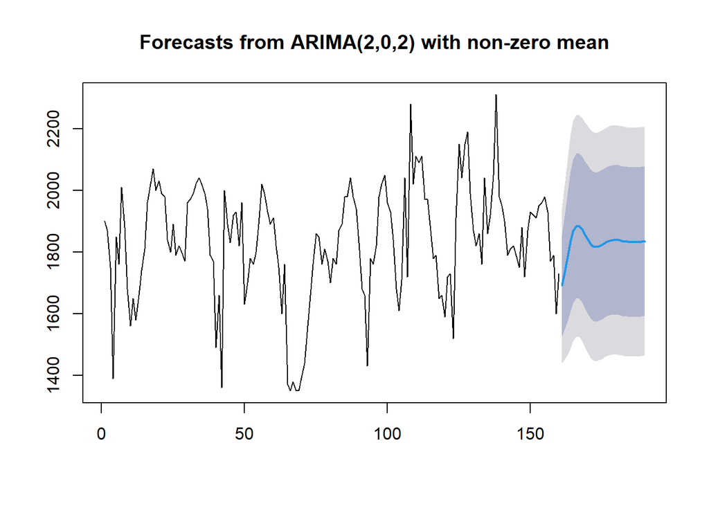

```r
data.ramalan.da <- ramalan.da$mean
plot(ramalan.da)
```

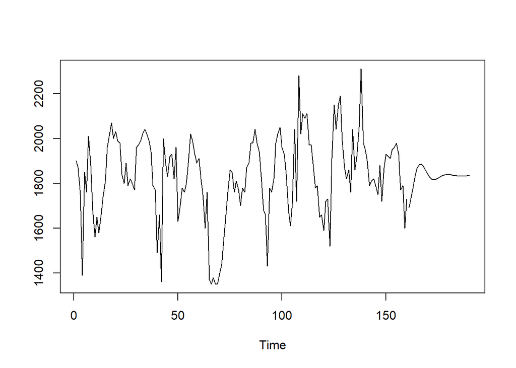

```r
hasil <- data.ramalan.da
ts.plot(train.ts,hasil)
```

```r
perbandingan.da<-matrix(data=c(head(test.ts, n=30), hasil[-1]),
                     nrow = 30, ncol = 2)
colnames(perbandingan.da)<-c("Aktual","Hasil Forecast")
perbandingan.da
```

```
##       Aktual Hasil Forecast
##  [1,]   1560       1733.168
##  [2,]   1740       1785.282
##  [3,]   1850       1833.125
##  [4,]   1960       1867.311
##  [5,]   1810       1884.211
##  [6,]   2000       1885.083
##  [7,]   1980       1874.381
##  [8,]   1910       1857.838
##  [9,]   1870       1840.821
## [10,]   1810       1827.244
## [11,]   1820       1819.126
## [12,]   1990       1816.686
## [13,]   1730       1818.820
## [14,]   1640       1823.727
```

[output cut: 16 more lines]

```r
accuracy(ts(hasil[-1]), head(test.ts, n=30))
```

```
##                 ME     RMSE      MAE       MPE     MAPE      ACF1 Theil's U
## Test set -76.86282 185.7462 129.1458 -5.550281 8.223749 0.4834826   1.42478
```